# Topic 2 - Regression

MSDA7003 - Machine Learning

KT Wong

Faculty of Social Sciences, HKU

2024-09-13

The materials in this topic are drawn from Lantz (2023) and James et al. (2023)

## Roadmap

1. Motivation
2. Understand Regression
3. Simple linear regression
4. Ordinary least squares (OLS)
5. Correlations
6. Multiple linear regression
7. An Example - launch
8. More details on multiple regression
9. Generalized linear models (very brief discussion if time is allowed)

## Motivation

- body weight is a function of one’s calorie intake
- income is often related to education and job experience
- poll numbers help to estimate a presidential candidate’s odds of being re-elected
- Some specific use in social science research:
  - Examining how populations and individuals vary by their measured characteristics
  - Identifying patterns to forecast future behavior given known criteria
    - predicting insurance claims
    - natural disaster damage
    - election results
    - crime rates
  - Quantifying the causal relationship between an event and its response
    - interest rate
    - policy
  - statistical hypothesis testing
    - whether a premise is likely to be true or false in light of observed data

## Motivation

### What we go to learn

- The basic statistical principles used in regression
- The key steps in the implementation
  - How to *prepare data* for regression analysis
  - *estimate* and *interpret* regression models
- How to *evaluate* the performance of a regression model
- How to *interpret* the results of a regression analysis
- aware of regression variants such as generalized linear models

## Understand Regression - Key ideas and components

- dependent variable
- independent variables
- Slope -intercept form (or coefficients, parameters)
  - The machine’s job is to identify values of slope and intercept such that the specified line is best able to relate the supplied $x$ values to the values of $y$
- simple linear regression
- multiple linear regression
- more advanced regression analysis
  - logistic regression
  - multinominal logistic regression
  - Poisson regression
  - generalized linear models (GLMs)

## Simple linear regression

- A simple linear regression model defines the relationship between a dependent variable and a single independent predictor variable

$$y=\alpha + \beta x +\varepsilon$$

- The key task: finding out parameter estimates for $\alpha$ and $\beta$

## Ordinary least squares (OLS)

- An estimation
- In OLS regression, the slope and intercept are chosen such that they **minimize** the sum of the squared errors (SSE)
- The errors ($\hat{\varepsilon}$ known as residuals) are the vertical distance between the **predicted y value** ($\hat{y}$) and the **actual y value** $y$
  - $\sum(y_i -\hat{y}_i)^2=\sum \hat{e}_i^2$
  - it is also called resudual sum of squares (RSS)
- The OLS method minimizes the sum of the squared errors
  - the minimizing values of $\alpha$ and $\beta$ are the OLS estimates

$$\begin{array}{rl}
\hat{\beta} &=& \frac{\sum(x_i-\bar{x})(y_i-\bar{y})}{\sum(x_i-\bar{x})^2} \\
\hat{\alpha} &=& \bar{y}-\hat{\beta}\bar{x}
\end{array}$$

## Ordinary least squares (OLS)

### using advertising data for illustration

- The dataset contains information on sales and advertising budgets for 200 different products
- The regression model is
  - $sales=\alpha + \beta \times TV + \varepsilon$

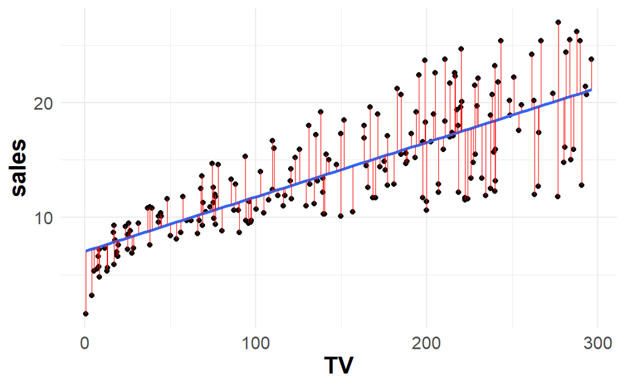

## Correlations

- we can make a contrast of correlation in the context of regression
- correlation typically refers to the Pearson correlation coefficient
- The correlation between two variables is a number that indicates how closely their relationship follows a straight line
- $\rho_{x,y}=Corr(x,y)= \frac{Cov(x,y)}{\sigma_x \sigma_y}$
- “correlation does not imply causation”

## Assess the accuracy of the coefficient estimates

- The standard error of the coefficient estimates is a measure of how much the coefficient estimates are likely to vary from the true population values

$$SE(\hat{\beta}_1) =\sqrt{\frac{\sigma^2}{\sum^n_{i=1}(x_i-\bar{x})^2}}, \quad
SE(\hat{\beta}_0)=\sqrt{\sigma^2 \left [ \frac{1}{n} +\frac{\bar{x}^2}{\sum^n_{i=1}(x_i-\bar{x})^2}\right ]}$$

$\textrm{where} \; \sigma^2=Var(\varepsilon)$

- standard errors can be used to compute confidence intervals

$$[\hat{\beta}_1-2 \cdot SE(\hat{\beta}_1), \hat{\beta}_1+2 \cdot SE(\hat{\beta}_1)]$$

- Also, $R^2$

$$R^2 =1- \frac{RSS}{TSS}, \quad \textrm{where} \quad TSS=\sum^n_{i=1}(y_i-\bar{y})^2$$

## Multiple linear regression

- A multiple regression model defines the relationship between a dependent variable and two or more independent predictor variables

$$Y_i=\alpha + \beta_1 X_{2i} + \cdots + \beta_k X_{pi} +\varepsilon_i$$

- how to interpret the coefficients, $\beta_j$
- The formula could be shown by using matrix notation

$$\mathbf{Y = X\beta + \varepsilon}$$

- the best estimate of the vector $\mathbf{\beta}$

$$\hat{\mathbf{\beta}}=(X^TX)^{-1}X^TY$$

## An Example - **launch**

- On January 28th, 1986, seven crew members of the United States space shuttle Challenger were killed when a rocket booster failed, causing a catastrophic disintegration
- In the aftermath, experts quickly focused on the launch temperature as a potential culprit
- The rubber O-rings responsible for sealing the rocket joints had never been tested below $4C^o$, and the weather on launch day was unusually cold and below freezing
- The rocket engineers almost certainly knew that cold temperatures could make the components more brittle and less able to seal properly, which would result in a higher chance of a dangerous fuel leak
- A regression model that demonstrated a link between temperature and O-ring failures, and could forecast the chance of failure given the expected temperature at launch, might have been very helpful

## An Example - **launch**

```
spc_tbl_ [23 × 4] (S3: spec_tbl_df/tbl_df/tbl/data.frame)
 $ distress_ct         : num [1:23] 0 1 0 0 0 0 0 0 1 1 ...
 $ temperature         : num [1:23] 66 70 69 68 67 72 73 70 57 63 ...
 $ field_check_pressure: num [1:23] 50 50 50 50 50 50 100 100 200 200 ...
 $ flight_num          : num [1:23] 1 2 3 4 5 6 7 8 9 10 ...
 - attr(*, "spec")=
  .. cols(
  ..   distress_ct = col_double(),
  ..   temperature = col_double(),
  ..   field_check_pressure = col_double(),
  ..   flight_num = col_double()
  .. )
 - attr(*, "problems")=<externalptr>
```

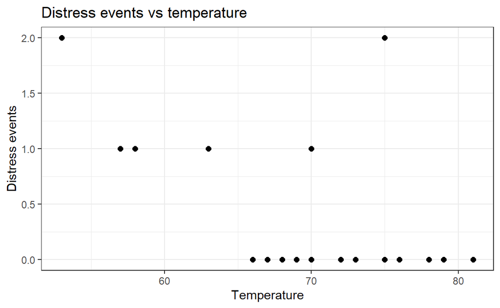

## An Example - **launch**

```
               estimate
Intercept    3.69841270
temperature -0.04753968
```

```
                         estimate
Intercept             3.527093383
temperature          -0.051385940
field_check_pressure  0.001757009
flight_num            0.014292843
```

- the coefficient for the temperature variable is negative
  - as temperature increases, the number of expected O-ring events decreases

## An Example - **launch**

```
Call:
lm(formula = distress_ct ~ temperature + field_check_pressure +
    flight_num, data = launch)

Residuals:
     Min       1Q   Median       3Q      Max
-0.65003 -0.24414 -0.11219  0.01279  1.67530

Coefficients:
                      Estimate Std. Error t value Pr(>|t|)
(Intercept)           3.527093   1.307024   2.699   0.0142 *
temperature          -0.051386   0.018341  -2.802   0.0114 *
field_check_pressure  0.001757   0.003402   0.517   0.6115
flight_num            0.014293   0.035138   0.407   0.6887
---
Signif. codes:  0 '***' 0.001 '**' 0.01 '*' 0.05 '.' 0.1 ' ' 1

Residual standard error: 0.565 on 19 degrees of freedom
Multiple R-squared:   0.36, Adjusted R-squared:  0.259
F-statistic: 3.563 on 3 and 19 DF,  p-value: 0.03371
```

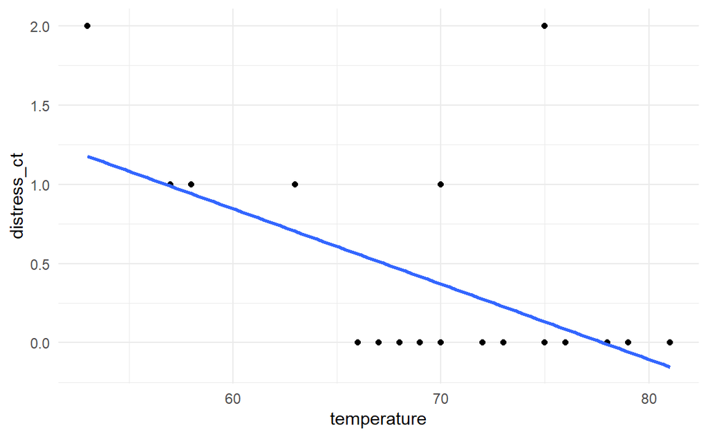

## Multiple Regression - A brief summary

| Strengths | Weaknesses |
| --- | --- |
| the most common to modeling numeric data | make strong assumptions about the data |
| can be adapted to model almost any modeling task | the model’s form must be specified |
| provides estimates of both the size and strength of the relationships among features and the outcome | influenced by missing data |
|  | categorical data requires additional preparation |
|  | require statistical knowledge to understand its working |

## Some considerations in the regeression models

- Some predictors are not quantitative but are `qualitative`, taking a discrete set of values
  - These are also called categorical predictors or factor variables
- let us use `credit card data` as an example
- The dataset contains information on credit card usage and payment behavior for 400 credit card holders
  - the response is balance (average credit card debt for each individual)
  - there are several quantitative predictors: age, cards (number of credit cards), education (years of education), income (in thousands of dollars), limit (credit limit), and rating (credit rating)
  - four `qualitative` variables
    - own (house ownership)
    - student (student status)
    - status (marital status)
    - region (East, West or South)

## Credit card data

```
spc_tbl_ [400 × 11] (S3: spec_tbl_df/tbl_df/tbl/data.frame)
 $ Income   : num [1:400] 14.9 106 104.6 148.9 55.9 ...
 $ Limit    : num [1:400] 3606 6645 7075 9504 4897 ...
 $ Rating   : num [1:400] 283 483 514 681 357 569 259 512 266 491 ...
 $ Cards    : num [1:400] 2 3 4 3 2 4 2 2 5 3 ...
 $ Age      : num [1:400] 34 82 71 36 68 77 37 87 66 41 ...
 $ Education: num [1:400] 11 15 11 11 16 10 12 9 13 19 ...
 $ Own      : chr [1:400] "No" "Yes" "No" "Yes" ...
 $ Student  : chr [1:400] "No" "Yes" "No" "No" ...
 $ Married  : chr [1:400] "Yes" "Yes" "No" "No" ...
 $ Region   : chr [1:400] "South" "West" "West" "West" ...
 $ Balance  : num [1:400] 333 903 580 964 331 ...
 - attr(*, "spec")=
  .. cols(
  ..   Income = col_double(),
  ..   Limit = col_double(),
  ..   Rating = col_double(),
  ..   Cards = col_double(),
  ..   Age = col_double(),
  ..   Education = col_double(),
  ..   Own = col_character(),
  ..   Student = col_character(),
  ..   Married = col_character(),
  ..   Region = col_character(),
  ..   Balance = col_double()
  .. )
 - attr(*, "problems")=<externalptr>
```

```
Call:
lm(formula = Balance ~ Income + Rating + Limit + Student + Married +
    Own + Region, data = creditcard)

Residuals:
    Min      1Q  Median      3Q     Max
-192.10  -79.88  -12.90   59.61  314.18

Coefficients:
              Estimate Std. Error t value Pr(>|t|)
(Intercept) -518.30561   23.01289 -22.522  < 2e-16 ***
Income        -7.94769    0.23570 -33.720  < 2e-16 ***
Rating         2.24120    0.41682   5.377 1.31e-07 ***
Limit          0.11855    0.02798   4.237 2.83e-05 ***
StudentYes   421.67162   16.99201  24.816  < 2e-16 ***
MarriedYes   -10.12849   10.52133  -0.963    0.336
OwnYes       -11.73807   10.13501  -1.158    0.248
RegionSouth   11.21263   12.47525   0.899    0.369
RegionWest    20.89711   14.40192   1.451    0.148
---
Signif. codes:  0 '***' 0.001 '**' 0.01 '*' 0.05 '.' 0.1 ' ' 1

Residual standard error: 101 on 391 degrees of freedom
Multiple R-squared:  0.9527,    Adjusted R-squared:  0.9517
F-statistic: 983.9 on 8 and 391 DF,  p-value: < 2.2e-16
```

## More details on multiple regression

### interactions and nonlinearity

- interactions
  - the effect of one predictor variable on the dependent variable depends on the value of another predictor variable
- nonlinearity
  - the relationship between the predictors and the dependent variable is not linear
- in our previous advertising example, we assumed that the effect on sales of increasing one advertising medium is independent of the amount spent on the other media
  - $\widehat{sales}=\hat{\alpha} + \hat{\beta}_1 \times TV + \hat{\beta}_2 \times Radio + \hat{\beta}_3 \times Newspaper$
- it could happen that given a fixed budget, instead of allocating the entire amount to either TV or to radio spending half on radio and half on TV may increase sales more
- in marketing research, this is known as a synergy effect
  - we call interaction effect in statistics analysis

## More details on multiple regression

### interactions and nonlinearity

Results from Advertising data

```
Call:
lm(formula = sales ~ TV + radio + newspaper + TV:radio, data = advert)

Residuals:
    Min      1Q  Median      3Q     Max
-6.2929 -0.3983  0.1811  0.5957  1.5009

Coefficients:
             Estimate Std. Error t value Pr(>|t|)
(Intercept) 6.728e+00  2.533e-01  26.561  < 2e-16 ***
TV          1.907e-02  1.509e-03  12.633  < 2e-16 ***
radio       2.799e-02  9.141e-03   3.062  0.00251 **
newspaper   1.444e-03  3.295e-03   0.438  0.66169
TV:radio    1.087e-03  5.256e-05  20.686  < 2e-16 ***
---
Signif. codes:  0 '***' 0.001 '**' 0.01 '*' 0.05 '.' 0.1 ' ' 1

Residual standard error: 0.9455 on 195 degrees of freedom
Multiple R-squared:  0.9678,    Adjusted R-squared:  0.9672
F-statistic:  1466 on 4 and 195 DF,  p-value: < 2.2e-16
```

## More details on multiple regression

### interactions using credit card data

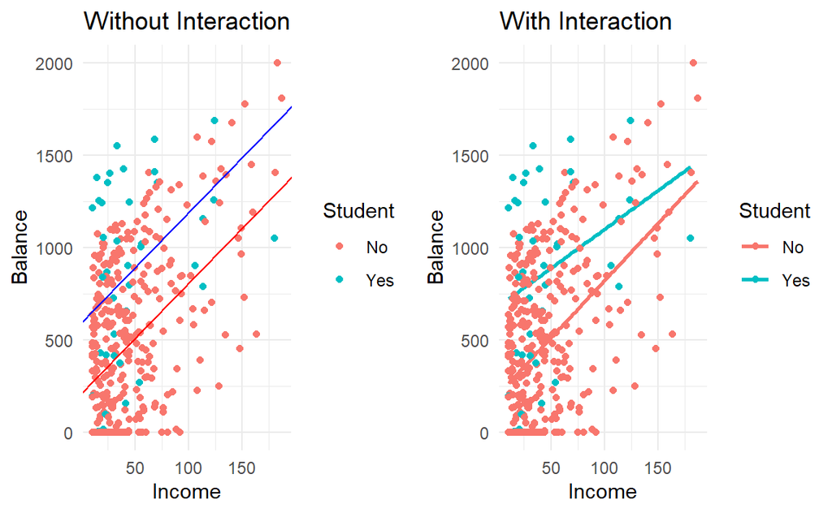

## Non-linear effects of predictors

- In some cases, the relationship between the predictors and the dependent variable is not linear
- The relationship between the predictors and the dependent variable can be modeled using polynomial regression

```
Call:
lm(formula = sales ~ TV + radio + newspaper + I(TV^2) + I(radio^2) +
    I(newspaper^2), data = advert)

Residuals:
    Min      1Q  Median      3Q     Max
-7.3614 -0.8808  0.0295  0.9767  3.3708

Coefficients:
                 Estimate Std. Error t value Pr(>|t|)
(Intercept)     1.411e+00  4.574e-01   3.085  0.00233 **
TV              7.809e-02  5.039e-03  15.497  < 2e-16 ***
radio           1.595e-01  2.843e-02   5.611 6.90e-08 ***
newspaper       1.012e-02  1.460e-02   0.693  0.48920
I(TV^2)        -1.123e-04  1.697e-05  -6.619 3.48e-10 ***
I(radio^2)      7.010e-04  5.751e-04   1.219  0.22433
I(newspaper^2) -1.226e-04  1.709e-04  -0.717  0.47416
---
Signif. codes:  0 '***' 0.001 '**' 0.01 '*' 0.05 '.' 0.1 ' ' 1

Residual standard error: 1.521 on 193 degrees of freedom
Multiple R-squared:  0.9176,    Adjusted R-squared:  0.915
F-statistic: 358.1 on 6 and 193 DF,  p-value: < 2.2e-16
```

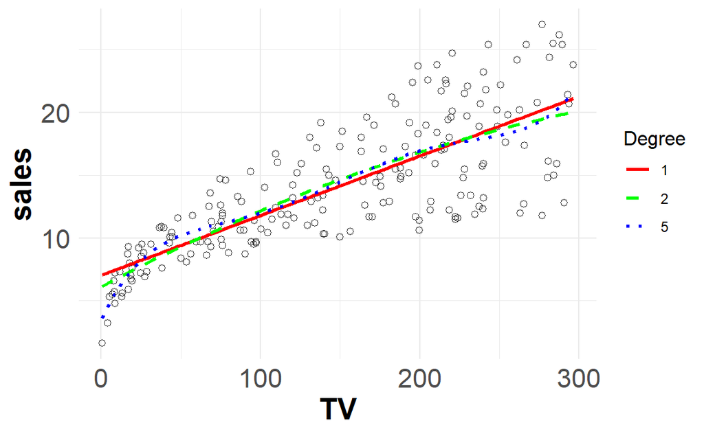

## Generalized linear models and logistic regression

- not every problem is well suited to being modeled by linear regression
- the statistical assumptions made by regression models are violated in many real-world tasks
- For modeling counting values, for categorical or binary outcomes, as well as other cases where the target is not a normally distributed continuous variable
  - standard linear regression is not the best tool for the job
- The GLM loosens two assumptions of traditional regression modeling:
  - it allows the target to be a non-continuous variable
  - it allows the variance of the target variable to be related to its mean (e.g. Poisson distribution)

## GLM

Two key components of any GLM:

1. the distribution of the target feature must be chosen from members of the [**exponential family** of distributions](https://en.wikipedia.org/wiki/Exponential_family)
   - includes the normal distribution, and Poisson, Binomial, and Gamma
2. The **link function** transforms the relationship between the predictors and the target so that it can be modeled using a linear equation, `despite the original relationship being nonlinear`
   - there is always a canonical link function (determined by the chosen family)
   - in some cases, one may choose a different link to vary how the model is interpreted or to obtain a better model fit

## GLM - some examples

| Family | Canonical Link Function | Target Range | Notes and Applications |
| --- | --- | --- | --- |
| Gaussian | Identity | (-∞, ∞) | Standard linear regression |
| Poisson | Log | Non-negative integers | Models the count of an event occurring by estimating the frequency at which the event happens |
| Binomial | Logit | [0, 1] | Used for modeling a binary outcome by estimating the probability that the outcome occurs |
| Gamma | Negative inverse | (0, ∞) | One of many possibilities for modeling right-skewed data; could be used for modeling the time to an event or cost data |
| Multinomial | Logit | K categories | Used for modeling a categorical outcome by estimating the probability the case falls into each of the categories |

## GLM - more discussions

- in the domain of machine learning, interpreting and understanding are less important than being able to apply the correct GLM form to practical problems and produce **useful predictions**
- generalized linear models use a different technique called **maximum likelihood estimation (MLE)**, which finds the parameter values for the specified distribution that are most likely to have generated the observed data
- The MLE technique is built into GLM modeling software, and usually applies analytical techniques to identify the optimal model parameters by iterating repeatedly over the data rather than finding the correct solution directly
- next time, we will start discussing classification problems
  - one important model is logistic regression

## References

James, G., D. Witten, T. Hastie, and R. Tibshirani. 2023. *An Introduction to Statistical Learning with Applications in r*. Second edition. Springer.

Lantz, Brett. 2023. *Machine Learning with r : Learn Techniques for Building and Improving Machine Learning Models, from Data Preparation to Model Tuning, Evaluation, and Working with Big Data*. Fourth edition. Expert Insight. Birmingham, UK: Packt Publishing Limited.